# Regresión lineal (Modelo estadístico)

```r
# importar una libreria que contiene conjuntos de datos
library(datasets)

df_iris <- datasets::iris

# head() me muestra los primero registros
head(df_iris)
```

A data.frame: 6 × 5

|  | Sepal.Length <dbl> | Sepal.Width <dbl> | Petal.Length <dbl> | Petal.Width <dbl> | Species <fct> |
| --- | --- | --- | --- | --- | --- |
| 1 | 5.1 | 3.5 | 1.4 | 0.2 | setosa |
| 2 | 4.9 | 3.0 | 1.4 | 0.2 | setosa |
| 3 | 4.7 | 3.2 | 1.3 | 0.2 | setosa |
| 4 | 4.6 | 3.1 | 1.5 | 0.2 | setosa |
| 5 | 5.0 | 3.6 | 1.4 | 0.2 | setosa |
| 6 | 5.4 | 3.9 | 1.7 | 0.4 | setosa |

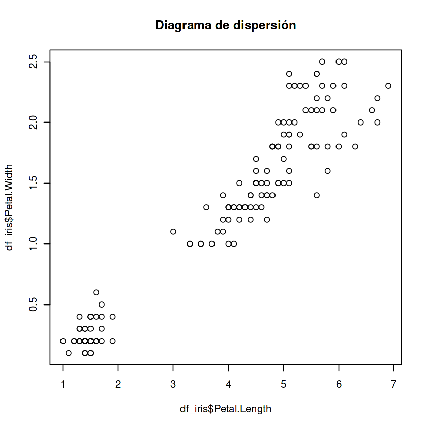

```r
# diagrama de dispersion
plot(x=df_iris$Petal.Length, y=df_iris$Petal.Width,
     main="Diagrama de dispersión")
```

# Implementación del modelo estadístico

```r
# Ajuste de la regresion lineal
#                 y ~ x
fit <- lm(Petal.Width~Petal.Length, data=df_iris)

# Una especie de resumen del modelo
summary(fit)
```

```
Call:
lm(formula = Petal.Width ~ Petal.Length, data = df_iris)

Residuals:
     Min       1Q   Median       3Q      Max
-0.56515 -0.12358 -0.01898  0.13288  0.64272

Coefficients:
              Estimate Std. Error t value Pr(>|t|)
(Intercept)  -0.363076   0.039762  -9.131  4.7e-16 ***
Petal.Length  0.415755   0.009582  43.387  < 2e-16 ***
---
Signif. codes:  0 ‘***’ 0.001 ‘**’ 0.01 ‘*’ 0.05 ‘.’ 0.1 ‘ ’ 1

Residual standard error: 0.2065 on 148 degrees of freedom
Multiple R-squared:  0.9271,	Adjusted R-squared:  0.9266
F-statistic:  1882 on 1 and 148 DF,  p-value: < 2.2e-16
```

La prueba F de la tabla ANOVA nos dice si la variable $x$ y $y$ están relacionadas.

- H0: La variable $x$ y $y$ no están relacionadas.
- H1: La variable $x$ y $y$ están relacionadas.

1) p-value<0.05

$R^{2}=0.9271$

$R^{2}$: qué tan bien explica la variable $x$ a la variable $y$.

$0\leq R^{2}\leq1$

- mientras más cerca este de 1, mejor es el modelo
- mientras más cerca este de 0, peor es el modelo

0.7 el modelo es bueno

beta cero gorrito = -0.363

beta uno gorrito = 0.4157

$\hat{\beta_{0}}=-0.363$

$\hat{\beta_{1}}=0.4157$

La ecuación de la recta de regresión es:

$y=\hat{\beta_{0}}+\hat{\beta_{1}}x$

$y=-0.363+0.4157x$

# Análisis de supuestos:

1. Los errores se distribuyen normal

```r
# importar la libreria broom que calcula los errores
# e_i
library(broom)

# Mas info y estadisticas sobre las observaciones
Datosfit <- augment(fit)

# Almacenamos los errores en una nueva variable
errores <- Datosfit$.std.resid

# Prueba de hipotesis: Shapiro-Wilk
shapiro.test(errores)
```

```
	Shapiro-Wilk normality test

data:  errores
W = 0.98379, p-value = 0.07524
```

- H0: los errores viene de una distribución normal
- H1: los errores NO viene de una distribución normal

p-value=0.075 > 0.05 nos quedamos con H0

El supuesto número 2, se está cumpliendo.

1. La varianza es constante

```r
# Prueba de hipotesis: Breusch-Pagan
# Se requieren de esas librerias:
library(lmtest)
library(zoo)

# con la funcion bptest:
bptest(fit)
```

```
	studentized Breusch-Pagan test

data:  fit
BP = 28.913, df = 1, p-value = 7.569e-08
```

p-value=0.0000000756<0.05 ---> H1

- H0: la varianza es constante
- H1: la varianza NO es constante

El supuesto 3 no se está cumpliendo:

- Transformar los datos
- Optar por otro modelo estadístico.

# Clase de la tarde

```r
1
```

1